# Multidimensional scaling

In MDS we start from a distance matrix, i.e. a matrix where the entries are differences between observations. Lets consider a regular tetrahedron with sides of length 1. All points are 0 away from itself and 1 away from all other points. This gives the following matrix.

```python
import numpy as np
D = np.array([[0,1,1,1], [1,0,1,1], [1,1,0,1], [1,1,1,0]])
print(D)
```

```
[[0 1 1 1]
 [1 0 1 1]
 [1 1 0 1]
 [1 1 1 0]]
```

What we want to do is to find coordinates (vectors) $\mathbf{x_1}$, $\mathbf{x_2}$, $\mathbf{x_3}$, $\mathbf{x_4}$ such that the distances between these points are as defined in the distance matrix $D$.

Now the distance between $\mathbf{x_1}$, $\mathbf{x_2}$ (which we write $d(\mathbf{x_1}$, $\mathbf{x_2})$) is the length of $\mathbf{x_1} - \mathbf{x_2}$, which is the square root of the inner product of $\mathbf{x_1} - \mathbf{x_2}$ with itself. However, to make things easier for ourselves, we work with the squared distance matrix, i.e. $D$ is understood to contain the square distance between two points.

$$ d^2(\mathbf{x_1} - \mathbf{x_2}) = (\mathbf{x_1} - \mathbf{x_2}) \cdot (\mathbf{x_1} - \mathbf{x_2})$$

If the vectors have $K$ dimensions, writing ${x_{1k}}$ for the $k$th component of $\mathbf{x_1}$, this is given by

$$ \sum_{k=1}^{K} ({x_{1k}} - {x_{2k}})^2 = \sum_{k=1}^{K} {x_{1k}}^2 + {x_{2k}}^2 - 2{x_{1k}}{x_{2k}} = \sum_{k=1}^{K} {x_{1k}}^2 + \sum_{k=1}^{K} {x_{2k}}^2 - 2\sum_{k=1}^{K} {x_{1k}}{x_{2k}} $$

Now these three sums are just the dot products $\mathbf{x_1} \cdot \mathbf{x_1}$, $\mathbf{x_2} \cdot \mathbf{x_2}$ and $\mathbf{x_1} \cdot \mathbf{x_2}$. So we have

$$ d^2(\mathbf{x_1} - \mathbf{x_2}) = (\mathbf{x_1} \cdot \mathbf{x_1}) + (\mathbf{x_2} \cdot \mathbf{x_2}) - 2 (\mathbf{x_1} \cdot \mathbf{x_2}) $$

From a set of vectors $\{x_1, \dots x_k\}$ we can construct the Gram matrix $B = X^TX$ such that $B_{i,j} = x_i \cdot x_j$. Written in terms of $B$ we get

$$ d^2(\mathbf{x_i}, \mathbf{x_j}) = B_{i,i} + B_{j,j} - 2B_{i,j}$$

So we want to construct $B$ from $D$. Then we will see how to recover $\{x_1, \dots x_k\}$ from $B$.

## Constructing $B$ from $D$

There is no unique solution. However, we will assume that the points in $X$ are *centered*, i.e. all rows and columns sum to 0.

$$\sum_{i=1}^n x_{i,k} = \sum_{i=1}^n x_{k, i} = 0 $$

for all $k$. So the same holds for $B$:

$$\sum_{i=1}^n B_{i,j} = \sum_{i=1}^n \sum_{k=1}^n x_{i,k} x_{j, k} = 0$$

for all $j$.

What else do we know about $B$? Consider first the sum of all (squared) distances from the points $\mathbf{x_1}, \dots \mathbf{x_n}$ to some fixed point $\mathbf{x_j}$. We write $T$ for the trace of $B$, i.e. the sum on the diagonal of $B$.

$$\sum_{i=1}^n d^2(\mathbf{x_i}, \mathbf{x_j}) = \sum_{i=1}^n B_{i,i} + B_{j,j} - 2B_{i,j} = \sum_{i=1}^n B_{i,i} + \sum_{i=1}^n B_{j,j} - \sum_{i=1}^n 2B_{i,j} = T + n B_{j,j} - 0$$

Because of centering, $\sum_{i=1}^n 2B_{i,j}$ is 0. Similary when we sum over the other index. A bit more tricky is

$$\sum_{j=1}^n \sum_{i=1}^n d^2(\mathbf{x_i}, \mathbf{x_j}) = \sum_{j=1}^n \sum_{i=1}^n B_{i,i} + B_{j,j} - 2B_{i,j} = \sum_{j=1}^n T + n B_{j,j} = \sum_{j=1}^n T + n \sum_{j=1}^n B_{j,j} = 2nT $$

In sum, when we have the following four equalities to help us construct $B$.

$$ d^2(\mathbf{x_i}, \mathbf{x_j}) = B_{i,i} + B_{j,j} - 2B_{i,j}$$$$\sum_{i=1}^n d^2(\mathbf{x_i}, \mathbf{x_j}) = T + n B_{j,j} - 0$$$$\sum_{j=1}^n d^2(\mathbf{x_i}, \mathbf{x_j}) = T + n B_{i,i} - 0$$$$\sum_{j=1}^n \sum_{i=1}^n d^2(\mathbf{x_i}, \mathbf{x_j}) = 2nT$$

The next part was hard to understand. However, as it turns out, one can prove from these that

$$B_{i, j} = -\frac{1}{2}\left(d^2(\mathbf{x_i}, \mathbf{x_j}) - d^2(\mathbf{x_i}, \cdot) - d^2(\cdot, \mathbf{x_j}) + d^2(\cdot, \cdot) \right)$$

The dot index notation denotes averages, so $d^2(\mathbf{x_i}, \cdot)$ is the mean of the $i$th row, $d^2(\cdot, \mathbf{x_j})$ the mean of the $j$th column and $d^2(\cdot, \cdot)$ the mean of all entries.

Here is how we can prove this. We start from the definition of $d^2$ in terms of $B$. $$ d^2(\mathbf{x_i}, \mathbf{x_j}) = B_{i,i} + B_{j,j} - 2B_{i,j}$$

Then we isolate $ B_{i,j}$, which will give us the entries of $B$. $$ B_{i,j} = -\frac{1}{2}\left(d^2(\mathbf{x_i}, \mathbf{x_j}) - B_{i,i} - B_{j,j}\right)$$

So how do we find $B_{i,i}$ and $B_{j,j}$? Turns out we can get that with some easy manipulation.

$$\sum_{j=1}^n d^2(\mathbf{x_i}, \mathbf{x_j}) = T + n B_{i,i}$$$$B_{i,i} = \frac{1}{n} \sum_{j=1}^n d^2(\mathbf{x_i}, \mathbf{x_j}) - T = d^2(\mathbf{x_i}, \cdot) - T $$

and similarly $$B_{j,j} = \frac{1}{n} \sum_{i=1}^n d^2(\mathbf{x_i}, \mathbf{x_j}) - T = d^2(\cdot, \mathbf{x_j}) - T $$

Inserting those two, we get

$$ B_{i,j} = -\frac{1}{2}\left(d^2(\mathbf{x_i}, \mathbf{x_j}) - (d^2(\mathbf{x_i}, \cdot) - T) - (d^2(\cdot, \mathbf{x_j}) - T)\right) = -\frac{1}{2}\left(d^2(\mathbf{x_i}, \mathbf{x_j}) - d^2(\mathbf{x_i}, \cdot) - d^2(\cdot, \mathbf{x_j}) + 2T\right) $$

Finally, we want to express $2T$ in terms of $d^2$. Some manipulation gives us that:

$$\sum_{j=1}^n \sum_{i=1}^n d^2(\mathbf{x_i}, \mathbf{x_j}) = 2nT$$$$2T = \frac{1}{n}\sum_{j=1}^n \sum_{i=1}^n d^2(\mathbf{x_i}, \mathbf{x_j}) $$$$2T = d^2(\cdot, \cdot) $$

We insert and get

$$ B_{i,j} = -\frac{1}{2}\left(d^2(\mathbf{x_i}, \mathbf{x_j}) - d^2(\mathbf{x_i}, \cdot) - d^2(\cdot, \mathbf{x_j}) + d^2(\cdot, \cdot)\right) $$

# Centering

Now we know how to construct the entries of $B$ from the distances in $D$. It turns out that instead of constructing each entry in this way, we can construct the whole matrix via matrix multiplication.

The [centering matrix](https://en.wikipedia.org/wiki/Centering_matrix) plays a crucial role in this construction. Its purpose is to remove the mean from a row or column. The centering matrix $C_n$ of size $n$ is defined as

$$C_n = I_n - \frac{1}{n}J_n$$

where $I$ is the identity matrix and $J_n$ is the matrix of all ones. In python terms:

```python
def centering_matrix(n):
     return np.eye(n) - np.ones((n,n)) / n
```

```python
print(centering_matrix(2))
print(centering_matrix(3))
```

```
[[ 0.5 -0.5]
 [-0.5  0.5]]
[[ 0.66666667 -0.33333333 -0.33333333]
 [-0.33333333  0.66666667 -0.33333333]
 [-0.33333333 -0.33333333  0.66666667]]
```

```python
def column_center(matrix):
    return centering_matrix(matrix.shape[0]) @ matrix
```

Lets try it out on some original matrix

```python
B = np.array([[0,2,3,4], [3,1,5,2], [2,2,2,2], [4,1,2,3]])
print(B)
print(column_center(B))
```

```
[[0 2 3 4]
 [3 1 5 2]
 [2 2 2 2]
 [4 1 2 3]]
[[-2.25  0.5   0.    1.25]
 [ 0.75 -0.5   2.   -0.75]
 [-0.25  0.5  -1.   -0.75]
 [ 1.75 -0.5  -1.    0.25]]
```

The entries have been shifted so that each column sums to 0, but their differences remain the same.

Right multiplying with $C_n$ will remove the means from the rows, and multiplying by $C_n$ on both sides will remove the mean from both rows and columns.

```python
def row_center(matrix):
    return matrix @ centering_matrix(matrix.shape[0])

def double_center(matrix):
    return centering_matrix(matrix.shape[0]) @ matrix @ centering_matrix(matrix.shape[0])
```

```python
print(row_center(B))
print(double_center(B))
```

```
[[-2.25 -0.25  0.75  1.75]
 [ 0.25 -1.75  2.25 -0.75]
 [ 0.    0.    0.    0.  ]
 [ 1.5  -1.5  -0.5   0.5 ]]
[[-2.125  0.625  0.125  1.375]
 [ 0.375 -0.875  1.625 -1.125]
 [ 0.125  0.875 -0.625 -0.375]
 [ 1.625 -0.625 -1.125  0.125]]
```

## Connecting the Gram matrix to centering.

It turns out there is a close connection between the Gram matrix $B$ and the centered distance matrix. This is perhaps not a surprise, as we saw above the the entries of $B$ were a multiple of $d^2(\mathbf{x_i}, \mathbf{x_j}) - d^2(\mathbf{x_i}, \cdot) - d^2(\cdot, \mathbf{x_j}) + d^2(\cdot, \cdot)$ where it sure looks like we are removing some means. (Although it it still unclear to me why we end up doing that when we construct an inner product matrix.)

To be more precise, lets look at some properties of centering. By the definition of the [matrix product](https://en.wikipedia.org/wiki/Matrix_multiplication) $CD$ and of the centering matrix $C$ we have:

$$ (CD)_{ij} = C_{i,} \cdot D_{,j} = (I_{i,} - \frac{1}{n}J_{i,}) \cdot D_{,j} = (I_{i,}\cdot D_{,j}) - (\frac{1}{n}J_{i,} \cdot D_{,j}) = D_{i,j} - \frac{1}{n}J_{i,} \cdot D_{,j} = D_{i,j} - D_{\cdot,j} $$

So left-multiplying by $C$ substracts the column mean from each entry. Similarly, right-multiplying by $C$ substracts the row mean from each entry:

$$ (DC)_{ij} = D_{i,}\cdot C_{,j} = D_{i,} \cdot (I_{,j} - \frac{1}{n}J_{,j})) = (D_{i,} \cdot I_{,j}) - (D_{i,} \cdot \frac{1}{n}J_{,j} ) = D_{i,j} - D_{i, \cdot}$$

And if we doubly center, we get:

$$((CD)(C))_{ij} = CD_{i,j} - CD_{i, \cdot} = D_{i,j} - D_{\cdot,j} - CD_{i, \cdot}$$

What can we say about $CD_{i, \cdot}$?

$$ CD_{i, \cdot} = \frac{1}{n}\sum_{j=1}^n D_{i,j} - D_{\cdot,j} = \frac{1}{n}\sum_{j=1}^n D_{i,j} - \frac{1}{n}\sum_{j=1}^n D_{\cdot,j} = D_{i, \cdot} - D_{\cdot, \cdot} $$

Inserting, we get

$$((CD)(C))_{ij} = D_{i,j} - D_{\cdot,j} - CD_{i, \cdot} = D_{i,j} - D_{\cdot,j} - (D_{i, \cdot} - D_{\cdot, \cdot}) = D_{i,j} - D_{\cdot,j} - D_{i, \cdot} + D_{\cdot, \cdot}$$

Intuitively, this means that when we doubly center a matrix, we subtract from each entry the mean of the row and of the column its in, and then we add the mean of all values.

Now recall that we showed above that

$$B_{i, j} = -\frac{1}{2} d_{ij}^2 - d_{i\cdot}^2 - d_{\cdot{}j}^2 + d_{\cdot\cdot}^2$$

We see that this is basically centering. In other words we can express B in terms of matrix multiplication.

$$ B = -\frac{1}{2}CDC$$

To conclude we have seen that when we doubly center the distance matrix $D$ we get (a multiple of) the Gram matrix of coordinates that bear these distances. The maths show it is so, but I honestly have no intuition why. (I saw mentioned that we have transformed the distance matrix into similarity scores, which may be a relevant intuition.)

## Testing out centering

Now we can apply this to our distance matrix. Notice that we should square the entries in the distance matrix, but since they are all 0 or 1, it does not matter.

```python
B = -0.5 * double_center(D)
print(B)
```

```
[[ 0.375 -0.125 -0.125 -0.125]
 [-0.125  0.375 -0.125 -0.125]
 [-0.125 -0.125  0.375 -0.125]
 [-0.125 -0.125 -0.125  0.375]]
```

Lets check that we can read off the distances from this matrix. Recall that $$ d^2(\mathbf{x_i}, \mathbf{x_j}) = B_{i,i} + B_{j,j} - 2B_{i,j}$$ So the distance between points 2 and 4, which is 1 according to $D$ should be $B_{2,2} + B_{4,4} - 2B_{2,4}$. In Python (with all indexing from 0), we get

```python
B[1,1] + B[3,3] - 2*B[1,3]
```

```
1.0
```

The distance between 3 and 3 should be zero and indeed it is

```python
B[2,2] + B[2,2] - 2*B[2,2]
```

```
0.0
```

Obviously this will always be the case when we compute the distance between a point and itself from B.

## From the Gram matrix to the coordinates

Now that we have $B$, we want to construct the underlying set of vectors $X$ that gives rise to $B$. (Recall that $B = X^TX$.) The idea is to use the [eigendecomposition](https://en.wikipedia.org/wiki/Eigendecomposition_of_a_matrix) (aka spectral decomposition) of $B$, which is a factorization of $B$ into a matrix $V$ of eigenvectors and a diagonal matrix $\Lambda$ of eigenvalues.

$B = V\Lambda V^{-1}$

Moreover, since $B$ is real and symmetric, its eigenvectors can be chosed real and orthogonal (see [slides here](http://www.seas.ucla.edu/~vandenbe/133B/lectures/symm.pdf)), which means that $V^{-1} = V^T$. So we get

$B = V\Lambda V^T$

Since $\Lambda$ is a diagonal matrix, we can easily take its square root $\Lambda^{\frac{1}{2}}$ by just taking the square roots of all the entries.

It is important that $V^{-1} = V^T$.

$B = X^TX = V\Lambda V^{T} = V\Lambda^{\frac{1}{2}}\Lambda^{\frac{1}{2}}V^{T}=(V\Lambda^{\frac{1}{2}})(\Lambda^{\frac{1}{2}}V^{T})$

We see clearly that $X = \Lambda^{\frac{1}{2}}V^{T}$, but also that this implies that $X^T = (\Lambda^{\frac{1}{2}}V^{T})^T = (V^T)^T(\Lambda^{\frac{1}{2}})^{T} = V\Lambda^{\frac{1}{2}}$ (because $\Lambda$ is diagonal and so its own transpose).

Without the equivalence of transpose and inverse, things are not so clear:

$B = X^TX = V\Lambda V^{-1} = V\Lambda^{\frac{1}{2}}\Lambda^{\frac{1}{2}}V^{-1}=(V\Lambda^{\frac{1}{2}})(\Lambda^{\frac{1}{2}}V^{-1})$

From this it follows that $X = \Lambda^{\frac{1}{2}}V^{-1}$. But it is not clear that $V\Lambda^{\frac{1}{2}} = X^T$. If $X = \Lambda^{\frac{1}{2}}V^{-1}$, we have $X^T = (\Lambda^{\frac{1}{2}}V^{-1})^T = (V^{-1})^T\Lambda^{\frac{1}{2}T}$, which I think is not $V\Lambda^{\frac{1}{2}}$ in the general case.

So we need to find the eigenvalues and -vectors of B. However, we need to be careful: [linalg.eig](https://numpy.org/doc/stable/reference/generated/numpy.linalg.eig.html) will return eigenvalues and eigenvectors, but they are not necessarily orthogonal. However, as we saw above, since B is real and symmetric, we can choose the eigenvectors to be orthogonal: [lingalg.eigh](https://numpy.org/doc/stable/reference/generated/numpy.linalg.eigh.html) does this. (Of course, it is our responsibility that the matrix is actually symmetric.)

```python
from numpy import linalg as LA

eigvals, V = LA.eigh(B)
#print(eigvals)
#print(V)
# eigh returns eigenvalues sorted ascending, we switch to descending and same for the eigenvector matrix
idx = eigvals.argsort()[::-1]
eigvals = eigvals[idx]
V = V[:,idx]
print(eigvals)
print(V)
```

```
[ 5.00000000e-01  5.00000000e-01  5.00000000e-01 -2.86153211e-30]
[[ 0.78930285 -0.35458203 -0.03567344  0.5       ]
 [-0.28112947 -0.00315044  0.81911922  0.5       ]
 [-0.54464403 -0.45763805 -0.493893    0.5       ]
 [ 0.03647065  0.81537052 -0.28955278  0.5       ]]
```

scipy is using a numerical algorithm to compute the eigenvalues, so we could end up with tiny negative numbers where we should have 0, for example. This might cause problems down the line, so it may make sense to change negative numbers to 0. Very small positive numbers are also a nuisance and often, as here, it's just a numerical approximate to 0. So we change all numbers below 1e-15 to 0.

```python
eigvals[eigvals<1e-15] = 0
print(eigvals)
```

```
[0.5 0.5 0.5 0. ]
```

Next, we create the matrix $\Lambda$ with the eigenvalues on the diagonal (np.diag does this) and take its square root, which we will call $L$.

```python
Lambda = np.diag(eigvals)
print(Lambda)
L = np.sqrt(Lambda)
print(L)
```

```
[[0.5 0.  0.  0. ]
 [0.  0.5 0.  0. ]
 [0.  0.  0.5 0. ]
 [0.  0.  0.  0. ]]
[[0.70710678 0.         0.         0.        ]
 [0.         0.70710678 0.         0.        ]
 [0.         0.         0.70710678 0.        ]
 [0.         0.         0.         0.        ]]
```

Let us now look at the vectors in V and check that they are orthonormal so that the transpose is the inverse.

```python
print(V)
print(V.T)
print(V @ V.T)
```

```
[[ 0.78930285 -0.35458203 -0.03567344  0.5       ]
 [-0.28112947 -0.00315044  0.81911922  0.5       ]
 [-0.54464403 -0.45763805 -0.493893    0.5       ]
 [ 0.03647065  0.81537052 -0.28955278  0.5       ]]
[[ 0.78930285 -0.28112947 -0.54464403  0.03647065]
 [-0.35458203 -0.00315044 -0.45763805  0.81537052]
 [-0.03567344  0.81911922 -0.493893   -0.28955278]
 [ 0.5         0.5         0.5         0.5       ]]
[[ 1.00000000e+00  6.16297582e-33  9.24446373e-33  9.24446373e-33]
 [ 6.16297582e-33  1.00000000e+00 -3.05311332e-16 -2.49800181e-16]
 [ 9.24446373e-33 -3.05311332e-16  1.00000000e+00 -2.22044605e-16]
 [ 9.24446373e-33 -2.49800181e-16 -2.22044605e-16  1.00000000e+00]]
```

Allowing for round-off errors, this is the case. Lets also check that our decomposition is correct, i.e. that $B = VLLV^T$ where $L=\Lambda^{\frac{1}{2}}$.

```python
print(B)
print(V @ L @ L @ V.T)
```

```
[[ 0.375 -0.125 -0.125 -0.125]
 [-0.125  0.375 -0.125 -0.125]
 [-0.125 -0.125  0.375 -0.125]
 [-0.125 -0.125 -0.125  0.375]]
[[ 0.375 -0.125 -0.125 -0.125]
 [-0.125  0.375 -0.125 -0.125]
 [-0.125 -0.125  0.375 -0.125]
 [-0.125 -0.125 -0.125  0.375]]
```

Perfect. Now we can create the coordinate matrix $X=LV^T$ that we wanted.

```python
X = L @ V.T
print(X)
```

```
[[ 0.5581214  -0.19878855 -0.38512149  0.02578864]
 [-0.25072735 -0.0022277  -0.32359897  0.57655402]
 [-0.02522493  0.57920476 -0.34923509 -0.20474474]
 [ 0.          0.          0.          0.        ]]
```

```python
print(X.sum(axis=1))
print(X.T @ X)
```

```
[2.01227923e-16 0.00000000e+00 1.11022302e-16 0.00000000e+00]
[[ 0.375 -0.125 -0.125 -0.125]
 [-0.125  0.375 -0.125 -0.125]
 [-0.125 -0.125  0.375 -0.125]
 [-0.125 -0.125 -0.125  0.375]]
```

We can also check whether these points really have distance 1 to each other:

```python
for i in range(4):
    for j in range(4):
        print(f"The distance from {i} to {j} is {LA.norm(X[:,i] - X[:,j])}")
```

```
The distance from 0 to 0 is 0.0
The distance from 0 to 1 is 0.9999999999999999
The distance from 0 to 2 is 0.9999999999999999
The distance from 0 to 3 is 0.9999999999999999
The distance from 1 to 0 is 0.9999999999999999
The distance from 1 to 1 is 0.0
The distance from 1 to 2 is 1.0
The distance from 1 to 3 is 1.0
The distance from 2 to 0 is 0.9999999999999999
The distance from 2 to 1 is 1.0
The distance from 2 to 2 is 0.0
The distance from 2 to 3 is 1.0
The distance from 3 to 0 is 0.9999999999999999
The distance from 3 to 1 is 1.0
The distance from 3 to 2 is 1.0
The distance from 3 to 3 is 0.0
```

## Dimensionality reduction and why eigenvalue decomposition was a good idea

Lets look at the eigenvalues and the coordinates again:

```python
print(L)
print(X)
```

```
[[0.70710678 0.         0.         0.        ]
 [0.         0.70710678 0.         0.        ]
 [0.         0.         0.70710678 0.        ]
 [0.         0.         0.         0.        ]]
[[ 0.5581214  -0.19878855 -0.38512149  0.02578864]
 [-0.25072735 -0.0022277  -0.32359897  0.57655402]
 [-0.02522493  0.57920476 -0.34923509 -0.20474474]
 [ 0.          0.          0.          0.        ]]
```

Each column gives the coordinates of one data point. There are four dimensions, although the last one is always zero. That's because we constructed $X$ as $LV^T$, and the fourth eigenvalue was 0. To see how this works, lets also look at $V^T$.

```python
print(V.T)
```

```
[[ 0.78930285 -0.28112947 -0.54464403  0.03647065]
 [-0.35458203 -0.00315044 -0.45763805  0.81537052]
 [-0.03567344  0.81911922 -0.493893   -0.28955278]
 [ 0.5         0.5         0.5         0.5       ]]
```

By the definition of matrix products, the columns of $X$ were created from the columns of $V^T$ by scaling each coordinate by the corresponding (square root of the) eigenvalue. That is, the data points will be the more distant along a dimension the higher the eigenvalue is. And if the eigenvalue is 0, all points will have coordinate zero. This means that this dimension contains no information and so we can drop it with no loss. That makes sense, since we started out with a tetrahedron and we know that the distances can be represented as points in 3D space -- there is no need for the fourth dimension.

Moreover, the three other eigenvalues are equal, all = 0.5. That also makes sense because we started with a regular polyhedron: all sides are equal and none of the three dimensions capture more distance than the others.

Let us now plot the tetrahedron in three dimensions. The first row contains the x-coordinates, the second the y-coordinates and the third the z-coordinates, while the fourth is uninformative.

```python
xs = X[0]
ys = X[1]
zs = X[2]
```

Now we draw lines between each of the points to see that we have a regular tetrahedron. We'll put the code inside a function for later reuse:

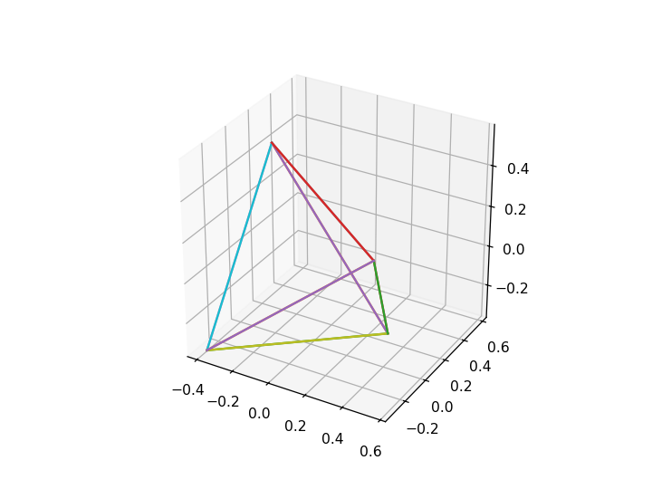

```python
%matplotlib notebook

import matplotlib.pyplot as plt
import itertools


def plot_tetrahedron(xs, ys, zs):
    fig = plt.figure()
    ax = plt.axes(projection='3d')
    ax.set_box_aspect((np.ptp(xs), np.ptp(ys), np.ptp(zs)))

    for edge in itertools.product([0,1,2,3], [0,1,2,3]):
        p1, p2 = edge
        ax.plot3D([xs[p1], xs[p2]], [ys[p1], ys[p2]], [zs[p1], zs[p2]])
    return

plot_tetrahedron(xs,ys,zs)
```

We can rotate this plot and check that it is a regular tetrahedron. But what if we wanted to plot this data in two dimensions? The fact that the eigenvalues are the same tells us that it does not matter which dimension we leave out: we will always lose one third of the distance information. Lets try plotting only x and y, or only x and z:

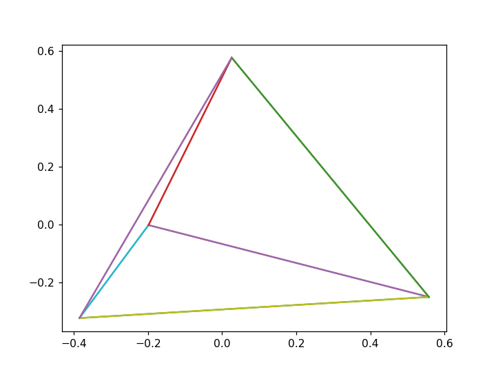

```python
fig = plt.figure()
ax = plt.axes()
for edge in itertools.product([0,1,2,3], [0,1,2,3]):
    p1, p2 = edge
    ax.plot([xs[p1], xs[p2]], [ys[p1], ys[p2]])
```

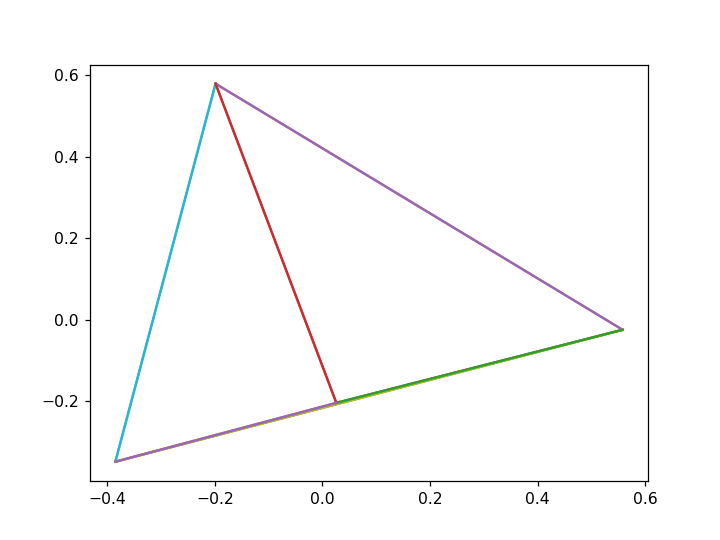

```python
fig = plt.figure()
ax = plt.axes()
for edge in itertools.product([0,1,2,3], [0,1,2,3]):
    p1, p2 = edge
    ax.plot([xs[p1], xs[p2]], [zs[p1], zs[p2]])
```

These look kind of different, so in what sense are they "equally good"? Since we know that in the orginal data, each point has distance 1 (more generally, we can look up the original distance in D) to all other points except itself, we can measure how good these plots are by computing the pairwise distance of all points and sum the square errors. It turns out that we get (more or less) the same number for both plots above.

```python
import math
error = 0
for edge in itertools.combinations([0,1,2,3], 2):
    p1, p2 = edge
    print(p1, p2)
    dist = math.sqrt((xs[p1] - xs[p2])**2 + (ys[p1] - ys[p2])**2)
    error += (D[p1,p2] - dist) ** 2
print(error)
```

```
0 1
0 2
0 3
1 2
1 3
2 3
0.5834398964685971
```

```python
error = 0
for edge in itertools.combinations([0,1,2,3], 2):
    p1, p2 = edge
    dist = math.sqrt((xs[p1] - xs[p2])**2 + (zs[p1] - zs[p2])**2)
    error += (D[p1,p2] - dist) ** 2
print(error)
```

```
0.5484584731771015
```

Before we go on, we will collect the code we have so far into a function that takes a distance matrix, does the multidimensional scaling, prints the eigenvalues and plots the coordinates in three dimensions

```python
# define a function to redo the MDS calculations, print the eigenvalues and plot the coordinates
def plot_mds(D):
    # remember from the theory that we work on a distance matrix with squared entries.
    # That did not play role when the distance was always 1, but in the general case it does.
    D = np.square(D)
    B = -0.5 * double_center(D)
    eigvals, V = LA.eigh(B)
    idx = eigvals.argsort()[::-1]
    eigvals = eigvals[idx]
    V = V[:,idx]
    eigvals[eigvals<1e-15] = 0
    Lambda = np.diag(eigvals)
    L = np.sqrt(Lambda)
    # print the eigenvalues
    print(L)
    X = L @ V.T
    xs = X[0]
    ys = X[1]
    zs = X[2]
    # compute sum of squared errors, using all three dimensions.
    error = 0
    for edge in itertools.combinations([0,1,2,3], 2):
        p1, p2 = edge
        dist = math.sqrt((xs[p1] - xs[p2])**2 + (ys[p1] - ys[p2])**2 + (zs[p1] - zs[p2])**2)
        error += (math.sqrt(D[p1,p2]) - dist) ** 2
    print(f"Error: {error}")
    plot_tetrahedron(xs,ys,zs)
```

## Varying the dimensions

Lets now think about situations where one dimension is more important (captures more distance data) than the others. One such situation is a tetrahedron which has an equilateral triangle with length = 1 as a base, but where we stretch the height. The length of the rising sides (i.e. the distances from the vertices of the base triangle to the top point) is $\sqrt{\frac{1}{3} + h^2}$

```python
def side(h):
    return math.sqrt(1/3 + h**2)
```

The distance matrix of such a tetrahedron will be as follows:

```python
def dist_matrix(h):
    s = side(h)
    return np.array([[0,1,1,s], [1,0,1,s], [1,1,0,s], [s,s,s,0]])
```

```python
print(dist_matrix(5))
print(np.square(dist_matrix(5)))
```

```
[[0.         1.         1.         5.03322296]
 [1.         0.         1.         5.03322296]
 [1.         1.         0.         5.03322296]
 [5.03322296 5.03322296 5.03322296 0.        ]]
[[ 0.          1.          1.         25.33333333]
 [ 1.          0.          1.         25.33333333]
 [ 1.          1.          0.         25.33333333]
 [25.33333333 25.33333333 25.33333333  0.        ]]
```

What we can observe now is that as we increase the height of the tetrahedron, one of the eigenvalues increase, showing that one dimension captures more of the distance data. If we set the height very high, this dimension dominates the distance data. Even the three-dimensional plot gives the impression of being just a line.

```
[[8.66025404 0.         0.         0.        ]
 [0.         0.70710678 0.         0.        ]
 [0.         0.         0.70710678 0.        ]
 [0.         0.         0.         0.        ]]
Error: 8.036520471939058e-30
```

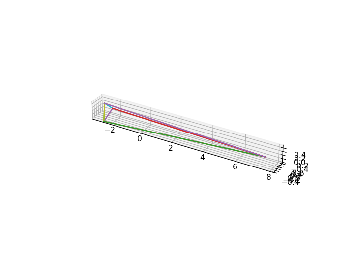

```python
# set the height here
D = dist_matrix(10)

plot_mds(D)
```

Moreover, when we set the height to 0, we get a distance matrix that corresponds to the three vertices of an equilateral triangle plus its centroid, i.e. the data are essentially two-dimensional as we can see if we rotate the plot accordingly. Therefore, we get only two non-null eigenvalues and a an essentially two-dimensional plot.

## Doing MDS directly in python

It is of course possible to do MDS directly in python without doing all the linear algebra operations. Here is how. MDS takes a number of parameters: precomputed dissimilarity tells MDS that we are passing a distance matrix (as opposed to having MDS compute that itself) and n_components gives the desired dimensionality. Notice that we must take care that the entries of the precomputed dissimilarity matrix are squared. MDS is invariant to rotations, so we might get different results (and different from those we have above) each time. Passing a random_state will (I believe) guarantee the same results whenever the seed is constant.

```
[[-3.14851309e-01 -1.35277397e-01 -3.87131713e-01]
 [ 4.96898409e-01 -1.46338441e-01  1.80644799e-03]
 [-1.81619203e-01  2.90428614e-01  3.83021743e-01]
 [-4.27896777e-04 -8.81277648e-03  2.30352182e-03]]
[[ 0.2828445   0.42685748  0.02940079]
 [-0.38793285 -0.02578664 -0.34263398]
 [ 0.11053615 -0.39930557  0.31053094]
 [-0.0054478  -0.00176527  0.00270226]]
```

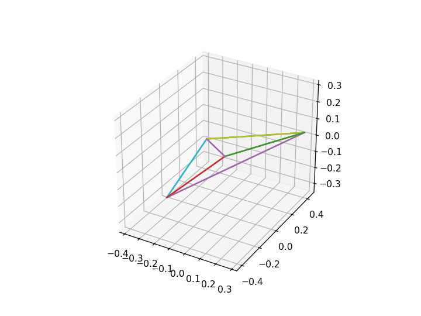

```python
D = np.square(dist_matrix(0))

from sklearn.manifold import MDS
mds = MDS(random_state=0, dissimilarity='precomputed', n_components=3)
scaled = mds.fit_transform(D)
print(scaled)

mds = MDS(dissimilarity='precomputed', n_components=3)
scaled = mds.fit_transform(D)
print(scaled)
xs = scaled[:,0]
ys = scaled[:,1]
zs = scaled[:,2]

plot_tetrahedron(xs,ys,zs)
```

If we rotate the above plot, we see that it is essentially two-dimensional. Let us see what happens if we deal with one-dimensional data. For example, the four points could just be the numbers 1, 7, 8 and 11 on a number line. This gives the following distance matrix:

```python
D = np.array([[0,6,7,10], [6,0,1,4], [7,1,0,3], [10,4,3,0]])
D = np.square(D)
print(D)
```

```
[[  0  36  49 100]
 [ 36   0   1  16]
 [ 49   1   0   9]
 [100  16   9   0]]
```

```
[[-41.05650016  20.41936417  -6.03916295]
 [  4.23797168  -2.05942391   0.60326412]
 [  9.11489027  -4.49707543   1.32671137]
 [ 27.70363821 -13.86286483   4.10918745]]
```

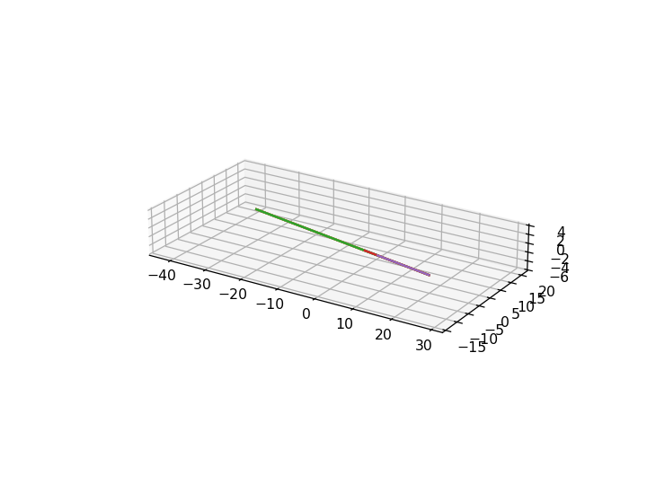

```python
mds = MDS(dissimilarity='precomputed', n_components=3)
scaled = mds.fit_transform(D)
print(scaled)
xs = scaled[:,0]
ys = scaled[:,1]
zs = scaled[:,2]

plot_tetrahedron(xs,ys,zs)
```

Same with our custom MCA code. We get only one non-null eigenvalue and the plot is simply a line (unless we are unlucky and get a negative eigenvalue due to rounding errors).

```python
D = np.array([[0,6,7,10], [6,0,1,4], [7,1,0,3], [10,4,3,0]])
plot_mds(D)
```

[output not shown]

```
[[7.26291952e+00 0.00000000e+00 0.00000000e+00 0.00000000e+00]
 [0.00000000e+00 7.19270416e-08 0.00000000e+00 0.00000000e+00]
 [0.00000000e+00 0.00000000e+00 0.00000000e+00 0.00000000e+00]
 [0.00000000e+00 0.00000000e+00 0.00000000e+00 0.00000000e+00]]
Error: 1.9721522630525295e-30
```